## Basic regression and classification models in R and some generalizations

## PDX Data Science Group

### Basic models for regression and classification

- Prototypical regression: linear model
  - R implementation: lm
- Prototypical classification: generalized linear model
  - R implementation: glm
- Useful to understand other models as generalizations of these
- Functions for other models in R generally follow same conventions as lm

### Linear model

- “Linear” because output (a.k.a. response or target) is a linear combination of other variables
- Input terms may comprise quadratic or other powers, trig/log functions, multiplicative terms, etc
- e.g. $y = \alpha_1 x_1^2 + \alpha_2 sin(x_2) + \alpha_3 x_3 x_4$ + noise is a linear model
- Inputs may be factors (i.e. categorical variables), otherwise inputs are considered quantitative variables

### R implementation: lm

- `my.model <- lm (y ~ ... (some formula), data=my.data)` where `data` is usually a data frame
- Formula:
  - `.` = all terms in data frame except for dependent variable
  - `+` for additive terms
  - `*` for additive terms plus interactions
  - `:` for interactions
  - `-` to remove terms
  - `+ 1` to include constant term (default)
  - `+ 0` to exclude constant term
  - `^` expands to `*` to specified degree
  - `%in%` = ???
- Variables in formula are names of columns in data frame, may appear with or without transformation e.g. `log(x)`, `sin(x)`

### lm example

```r
heights <- c(rnorm (20, mean=69, sd=8), rnorm (20, mean=64, sd=6))
my.data <- data.frame (height=heights,
  age= c(runif (40, min=20, max=80)),
  gender=c(rep("M", 20), rep("F", 20)))

model.1 <- lm (height ~ age, data=my.data)

summary (model.1)
```

```
##
## Call:
## lm(formula = height ~ age, data = my.data)
##
## Residuals:
##      Min       1Q   Median       3Q      Max
## -15.2593  -6.8983   0.2794   4.6774  19.0766
##
## Coefficients:
##             Estimate Std. Error t value Pr(>|t|)
## (Intercept) 67.65749    4.11383   16.45   <2e-16 ***
## age          0.01548    0.08133    0.19     0.85
## ---
## Signif. codes:  0 '***' 0.001 '**' 0.01 '*' 0.05 '.' 0.1 ' ' 1
##
## Residual standard error: 8.676 on 38 degrees of freedom
## Multiple R-squared:  0.0009529,  Adjusted R-squared:  -0.02534
## F-statistic: 0.03624 on 1 and 38 DF,  p-value: 0.85
```

```r
model.2 <- lm (height ~ gender, data=my.data)

summary (model.2)
```

```
##
## Call:
## lm(formula = height ~ gender, data = my.data)
##
## Residuals:
##      Min       1Q   Median       3Q      Max
## -13.8760  -5.4736  -0.9574   6.0228  15.7925
##
## Coefficients:
##             Estimate Std. Error t value Pr(>|t|)
## (Intercept)   65.056      1.783  36.479   <2e-16 ***
## genderM        6.680      2.522   2.648   0.0117 *
## ---
## Signif. codes:  0 '***' 0.001 '**' 0.01 '*' 0.05 '.' 0.1 ' ' 1
##
## Residual standard error: 7.976 on 38 degrees of freedom
## Multiple R-squared:  0.1558, Adjusted R-squared:  0.1336
## F-statistic: 7.014 on 1 and 38 DF,  p-value: 0.01171
```

```r
model.3 <- lm (height ~ age * gender, data=my.data)

summary (model.3)
```

```
##
## Call:
## lm(formula = height ~ age * gender, data = my.data)
##
## Residuals:
##     Min      1Q  Median      3Q     Max
## -13.936  -6.369  -1.027   6.059  15.774
##
## Coefficients:
##             Estimate Std. Error t value Pr(>|t|)
## (Intercept) 67.05350    4.86928  13.771 6.44e-16 ***
## age         -0.04604    0.10405  -0.443    0.661
## genderM      6.02171    8.20380   0.734    0.468
## age:genderM  0.02028    0.16036   0.126    0.900
## ---
## Signif. codes:  0 '***' 0.001 '**' 0.01 '*' 0.05 '.' 0.1 ' ' 1
##
## Residual standard error: 8.167 on 36 degrees of freedom
## Multiple R-squared:  0.1614, Adjusted R-squared:  0.09153
## F-statistic:  2.31 on 3 and 36 DF,  p-value: 0.09274
```

### Generalized linear model

- LM: $y = \mathrm{linear\ combination\ of\ } x + \mathrm{noise}$
- GLM: $f(y) = \mathrm{linear\ combination\ of\ } x + \mathrm{noise}$
  - $f$ = link function, choosing different link function creates a different model
  - also choosing different noise distribution creates a different model
- GLM brings different kinds of models under one roof; in particular logistic regression and other classification models
- Logistic regression = GLM with logit (log odds) link function, $\mathrm{logit}(y) = \log(y / (1 - y))$
  - i.e. GLM is $\mathrm{logit}(y) = \mathrm{linear\ combination\ of\ } x$
- Note if $\mathrm{logit}(y) = \mathrm{linear\ combination\ of\ } x$, then $y = 1/(1 + \exp(-(\mathrm{linear\ combination\ of\ } x)))$
- $1/(1 + \exp(-u)) = \mathrm{logistic\ function}$

### R implementation: glm

- `my.model ~ glm (y ~ ... (some formula), data=my.data, family=...)`
- ‘family’ is new here – it selects the link function and noise model
  - family=binomial => logit link function, logistic regression
  - family=gaussian => identity link function, linear regression
  - family=poisson => log link function, Poisson regression

### glm example

- construct made-up data

Let $x \sim N(0, I)$. Then $L x + \mu \sim N(\mu, \Sigma)$ where $\Sigma = L L'$.

```r
m1 <- c(25, 60)
L1 <- matrix (data=c(50, 30, 0, 40), nrow=2)
S1 <- L1 %*% t(L1)
pC1 <- 0.5

m2 <- c(74, 37)
L2 <- matrix (data=c(40, 24, 0, 12), nrow=2)
S2 <- L2 %*% t(L2)
pC2 <- 0.5

z1 <- matrix (data=rnorm(100), ncol=2)
x1 <- t(L1 %*% t(z1)) + matrix (data=m1, nrow=50, ncol=2, byrow=T)

z2 <- matrix (data=rnorm(100), ncol=2)
x2 <- t(L2 %*% t(z2)) + matrix (data=m2, nrow=50, ncol=2, byrow=T)
```

- display made-up data

Class 1 = green, class 2 = red.

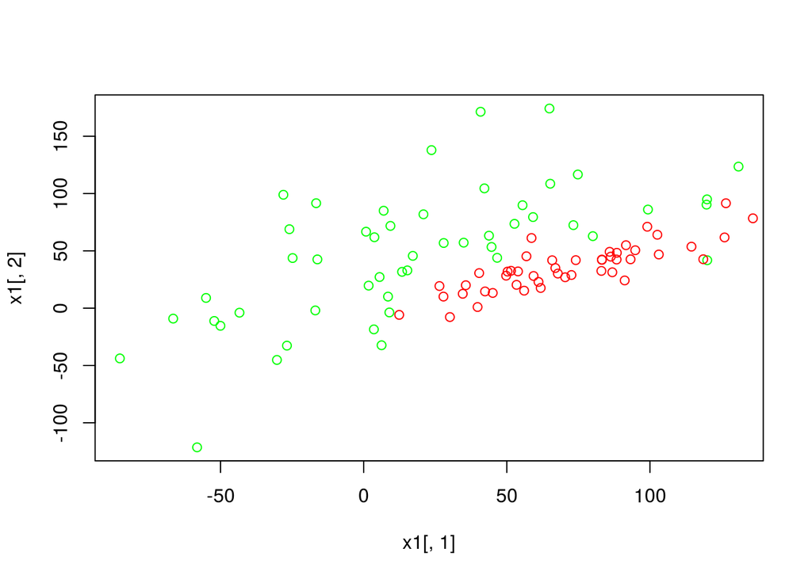

```r
plot (x1[,1], x1[,2], col='green')
points (x2[,1], x2[,2], col='red')
```

- build GLM

Put made-up data into a data frame. `label` = class label (50 of class 1, 50 of class 2), `X1` = first input dimension, `X2` = second input dimension.

```r
my.data <- data.frame (label=c(rep("C1", 50), rep("C2", 50)),
  X1=c(x1[, 1], x2[, 1]), X2=c(x1[, 2], x2[, 2]))

my.glm <- glm (label ~ X1 + X2, data=my.data, family=binomial)
```

- generate outputs

`type="link"` => output logit (log-odds) value, `type="response"` => output class probabilities

```r
head (predict (my.glm, type="link"))
```

```
##          1          2          3          4          5          6
## -1.1783295  1.7645425 -2.1725131 -7.7840178 -9.9160769  0.1747781
```

```r
head (predict (my.glm, type="response"))
```

```
##            1            2            3            4            5
## 2.353527e-01 8.537777e-01 1.022461e-01 4.161628e-04 4.937204e-05
##            6
## 5.435836e-01
```

- construct classification boundary

Draw the line such that logit(x) = 0, i.e., class probabilities are equal. Extract coefficients from model.

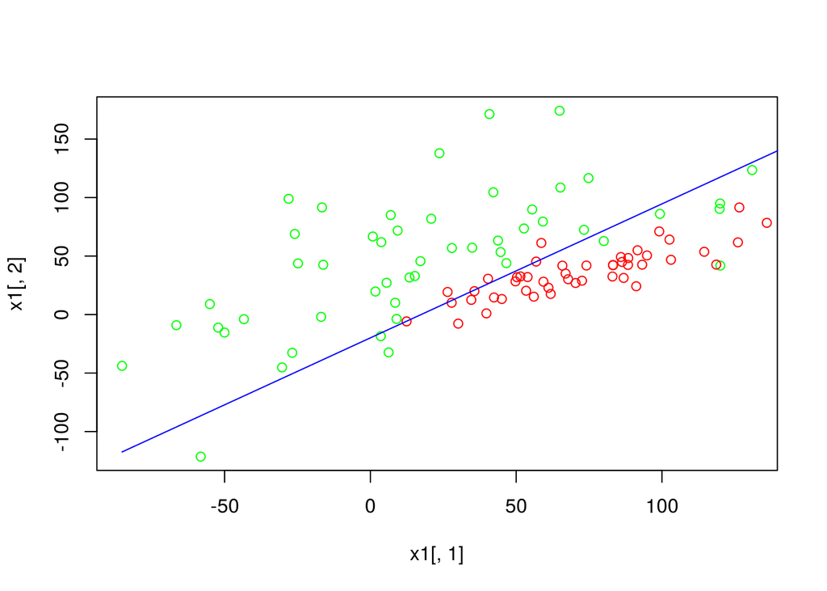

```r
foo <- function (a, x) { (a[[1]] + a[[2]]*x)/(-a[[3]]) }

xmin <- min (my.data[, 2])
xmax <- max (my.data[, 2])

plot (x1[,1], x1[,2], col='green')
points (x2[,1], x2[,2], col='red')
lines (c(xmin, xmax), c(foo (my.glm$coefficients, xmin), foo (my.glm$coefficients, xmax)), col='blue')
```

### Probabilistic interpretation of logistic regression

- Suppose $p(x | C_1)$ and $p(x | C_2)$ are some distributions (so-called generative distributions). Then the posterior class probability $p(C_1 | x)$ is

$\begin{aligned} p(C_1 | x) & = \frac{p(x | C_1) p(C_1)}{p(x)} \\ & = \frac{p(x | C_1) p(C_1)}{p(x | C_1) p(C_1) + p(x | C_2) p(C_2)} \\ & = \frac{1}{1 + \frac{p(x | C_2) p(C_2)}{p(x | C_1) p(C_1)}} \\ & = \frac{1}{1 + \mathrm{foo}} \\ & = \frac{1}{1 + \exp(- (-\log(\mathrm{foo})))} \\ & = \mathrm{logistic}(\log(\mathrm{1/foo})) \end{aligned}$

Note that $1/\mathrm{foo} = \frac{p(C_1 | x) p(x)}{p(C_2 | x) p(x)} = \frac{p(C_1 | x)}{p(C_2 | x)}$, i.e. posterior odds for class 1 versus class 2.

Let’s look at the log odds for normal distributions.

$\log(1/\mathrm{foo}) = \log(p(x | C_1)) - \log(p(x | C_2) + (\mathrm{stuff\ free\ of\ } x) \\ = - \frac{1}{2} (x - \mu_1)' \Sigma_1^{-1} (x - \mu_1) + \frac{1}{2} (x - \mu_2)' \Sigma_2^{-1} (x - \mu_2) + (\mathrm{stuff\ free\ of\ } x)$

Therefore

$\log(1/\mathrm{foo}) \propto - (x - \mu_1)' \Sigma_1^{-1} (x - \mu_1) + (x - \mu_2)' \Sigma_2^{-1} (x - \mu_2) + (\mathrm{stuff\ free\ of\ } x)$

That’s a linear (more precisely, affine) function of $x$, and its contours are hyperplanes.

### Logistic regression as a point of departure

- Allow different covariances => contours of log-odds are quadratics
- Allow distributions other than normal => contours are no longer conic sections
- Use class probabilities to compute expected loss => decision rule for classification
- Build model via generative distributions or via posterior log-odds
- Focus on boundaries, ignore probabilities => linear discriminant, SVM, CART

### Logistic regression and neural networks

- “Neural networks” are a generalization of logistic regression
- NN output = logistic(linear combination of logistic functions)

  => contours are softened piecewise hyperplanes (each piece corresponding to a hidden unit)
- Universal approximation: with enough pieces (hidden units), you can approximate any shape of boundary